# KRIP PE2 data

Here we load the KIRP PE2 data and perform a DE analysis and also look at counts for certain genes.

[output not shown]

```r
library("tidyverse")
library("DESeq2")
library("stringr")
library(EnhancedVolcano)

projectDir <- 'data/'

filename <- paste(projectDir, 'TCGA_kidney_counts_KIRP-PE2-only_13082020.csv', sep='')

# Read in the count matrix
counts <- read.csv(filename, header = TRUE, sep = ",")
# We want to rename the rows and make sure they are labeled by the gene_id (note you'll have to select whatever your ID column name is here)
" Set <gene_id> to be the column with the gene IDs "
```

```
[1] " Set <gene_id> to be the column with the gene IDs "
```

```r
rownames(counts) <- counts$gene_id
geneNames <- counts$gene_name
geneIds <- counts$gene_id

# select only the PE2 data
counts <- dplyr::select(counts,contains("PE2"))

# Here we get the names of the columns, for my stuff I always have all the info in one string as I find it makes it easier
# this means each of the "groups" are separated by a "_" this may be different for you
sampleNames <- colnames(counts) # Sample names

# Lets get the names of the different factors
splitSampleNames <- str_split(sampleNames, '_')
project <- sapply(splitSampleNames, function(x){x[2]})
sampleType <- sapply(splitSampleNames, function(x){x[3]})
gender <- sapply(splitSampleNames, function(x){x[4]})
race <- sapply(splitSampleNames, function(x){x[5]})
tumourStage <- sapply(splitSampleNames, function(x){x[6]})

# For DEseq2 we need to turn this into a dataframe
sampleDF = data.frame(project = project, sampleType = sampleType,
                      gender = gender, race = race, tumourStage = tumourStage)

# Make sure we don't include the ID in our columns
countMatrix <- as.matrix(counts)

# We now set the row names to be the gene IDs
rownames(countMatrix) <- geneNames

# Remove Nans
countMatrix[is.nan(countMatrix)] <- 0
```

## Starting the DEseq2 Analysis

Now we can start to run the DEseq2 analysis or the EdgeR, both use the data in the above format.

First we want to set the design for the experiment, from the above webpage:

> If the research aim is to determine for which genes the effect of treatment is different across groups, then interaction terms can be included and tested using a design such as ~ group + treatment + group:treatment.

For us since we’re looking at TCGA maybe we want to look at our treatment as sampleTypes e.g. “Tumour” vs “PrimaryTissueNormal” and our groups as gender e.g: “female”, “male”.

```r
ddsMat <- DESeqDataSetFromMatrix(countData = countMatrix,
                                 colData = sampleDF,
                                 design = ~ sampleType)
```

```
6 duplicate rownames were renamed by adding numberssome variables in design formula are characters, converting to factors
```

### Prefiltering data

Note the more samples that are kept, the more statistical tests you need to perform, thus they will need to pass a higher FDR. It may be important here to filter many of the not so good genes if you wish to pick up on smaller changes such as transcription factors, or more variable genes such as cell cycle genes.

```r
numSamplesMeetingCriteria <- 8
numCountsInGene <- 2
keep <- rowSums(counts(ddsMat) >= numCountsInGene) >= numSamplesMeetingCriteria
dds <- ddsMat[keep,]

# Let's print the number of rows
nrow(dds)
```

```
[1] 18005
```

### Normalising data for exploration

While we don’t need to normalise the data for performing differential expression, it is good to normalise it for visualisation, e.g. when we do a PCA. This is because PCA aims to maximise the captured variance which without normalisation will capture the genes with the highest counts. The tutorial recommends either *Variance stabilising transformation* (VST) (for medium to large datasets e.g. n > 30) or *rlog* (small datasets). These are preferred over just taking the *log transform* as in the log transform small count variances are over exemplified. I will just use VST since I have large datasets.

### Visualising of the data

We’ll perform two visualisations:

[output not shown]

For both of these we’ll use the normalised data (by VST).

#### PCA

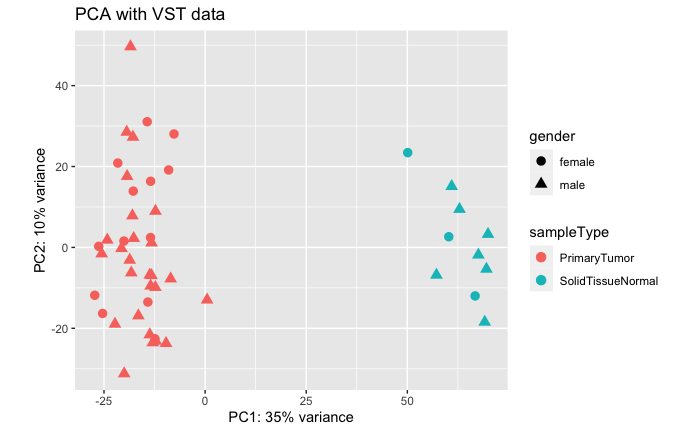

### Running DE analysis

Now we’ll actually run the DEseq analysis using what we designed before.

#### Results columns explained

> baseMean: average of the normalized count values, divided by the size factors, taken over all samples in the DESeqDataSet log2FoldChange: effect size estimate e.g. how much a gene’s expression has changed as a result of the treatment (or in our case tumour) lfcSE: uncertainty (standard error estimate) for the log2FoldChange pvalue: the likelihood that the effect observed occured by chance (e.g. by experimetal variability etc)

Note: 1) alpha = p-value i.e. significance –> usually 0.05 (will have high FDR) 2) padj = FDR adjusted p values (by BH) –> usually 0.05 or 0.1 3) lfcThreshold = log fold change threshold –> usually 1.0

```r
# Run DEseq2
dds <- DESeq(dds)
```

```
-- replacing outliers and refitting for 843 genes
-- DESeq argument 'minReplicatesForReplace' = 7
-- original counts are preserved in counts(dds)
```

```r
# Build results table
res <- results(dds)

# Sumarise the results
summary(res)
```

```
out of 18005 with nonzero total read count
adjusted p-value < 0.1
LFC > 0 (up)       : 3623, 20%
LFC < 0 (down)     : 4657, 26%
outliers [1]       : 0, 0%
low counts [2]     : 0, 0%
(mean count < 0)
[1] see 'cooksCutoff' argument of ?results
[2] see 'independentFiltering' argument of ?results
```

```r
# Lastly, we may want to see the results of the high logfoldchange e.g. > 1 with a padj value < 0.05
table(res$padj < 0.05)
```

```
FALSE  TRUE
10983  7022
```

### Having a look at the distribution of specific genes

```r
log2Counts <- log2(countMatrix + 1)

" Get the genes of interest "
```

```
[1] " Get the genes of interest "
```

```r
geneOfInterest <- c('PFKFB1' ,'HIRA')
geneRow <- log2Counts[rownames(log2Counts) %in% geneOfInterest, ]
colnames(geneRow) <- sampleType
geneRow <- t(geneRow)
geneRow <- cbind(sampleType, data.frame(geneRow, row.names=NULL))

# Plot the normal and then the tumour for both rows
# We have 39 tumour and 9 normal (note there may be duplicates for some patients)
p <- ggplot(geneRow, aes(x=sampleType, y=HIRA, fill=sampleType)) +
  geom_violin()
p <- p + geom_dotplot(binaxis='y', stackdir='center', dotsize=) + ggtitle("Log2 + 1 counts HIRA")
ggsave(
  "Log2CountsHIRA.png",
  plot = last_plot())
# Plot the normal and then the tumour for both rows
# We have 39 tumour and 9 normal (note there may be duplicates for some patients)
p <- ggplot(geneRow, aes(x=sampleType, y=PFKFB1, fill=sampleType)) +
  geom_violin()
p <- p + geom_dotplot(binaxis='y', stackdir='center', dotsize=) + ggtitle("Log 2 + 1 counts PFKFB1")
ggsave(
  "Log2CountsPFKFB1.png",
  plot = last_plot())
```

[figure not shown]

```r
p <- ggplot(geneRow, aes(x=sampleType, y=HIRA, fill=sampleType)) +
  geom_violin()
p <- p + geom_dotplot(binaxis='y', stackdir='center', dotsize=) + ggtitle("Raw counts HIRA")
p
ggsave(
  "RawCountsHIRA.png",
  plot = last_plot())
```

[figure not shown]

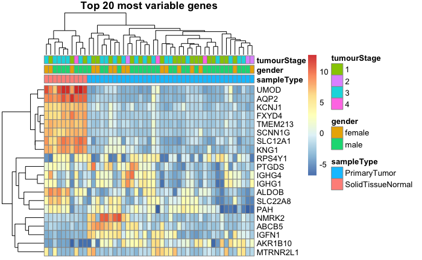

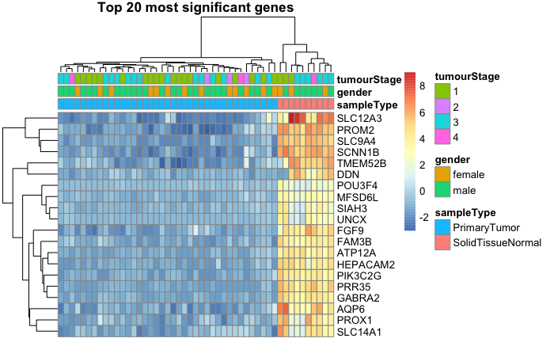

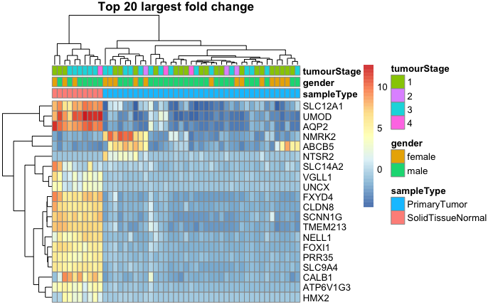